# A data-driven analysis for our start-up: INNOvALGAE

## Have you ever wandered about the consequences of using chemical colors?

Two of the main industries where they are used are *cosmetics* and *textiles*.

The main danger from the use of these artificial colors are *wastewaters*: rich of dangerous substances like toxins and heavy metals.

These waters end up in sea and rivers, and consequentely in the food we eat.

When it comes to *cosmetic products*, safety concerns are rising: they can directly alter the skin, causing toxic effects on the long term.

## Solution: the use of biologic molecules

Natural molecules can avoid us the use of chemical colorants.

One of them, *Phycocyanin*, is the only blue dye found in nature.

Phycocyanin can be extracted from a microalgae: Spirulina.

Spirulina and Phycocyanin have several beneficial properties on our organism. They are also eco-friendly, free of waste and their production absorbs CO2 from the environment.

This is the reason why we are launching our start-up: *INNOvALGAE*.

## Goal of this research

The goal of this research is to find informations on the *common sentiment* about sustainability, climate change, chemical colorants and Spirulina/Phycocyanin.

These informations will help us evaluate the current situation, find cues about customers’ beliefs and guide our business decisions.

## Data collection

We have build a set of interesting *keywords*, grouped by *themes*.

Then we have fed the keywords to a *custom web crawler* which:

- searches the keywords in Google News;
- downloads a processes the articles;
- saves them to csv files.

The crawler was written in Python, while the analysis was performed using R.

## Themes

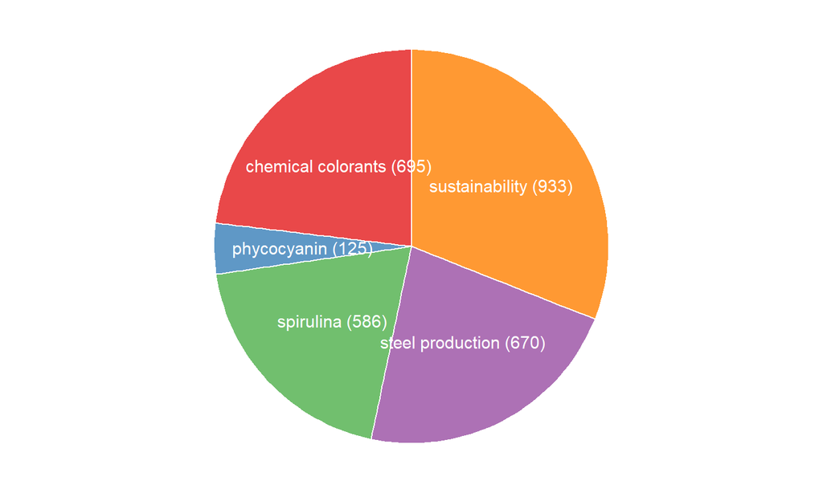

## Keywords

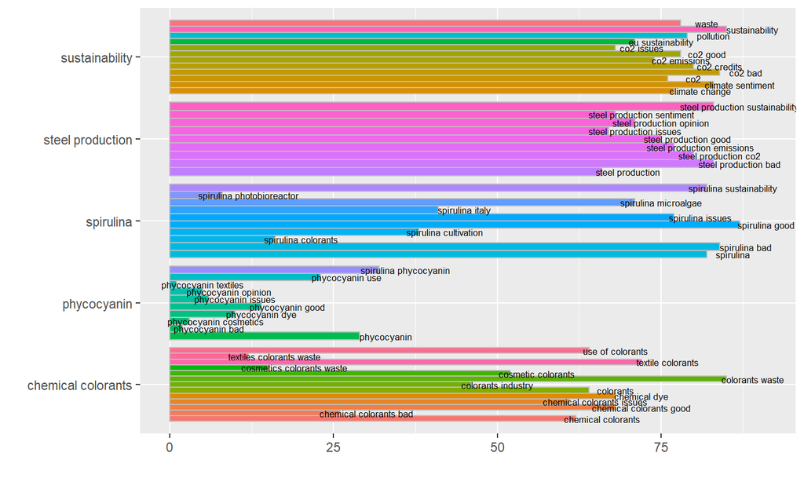

## Searched Keywords

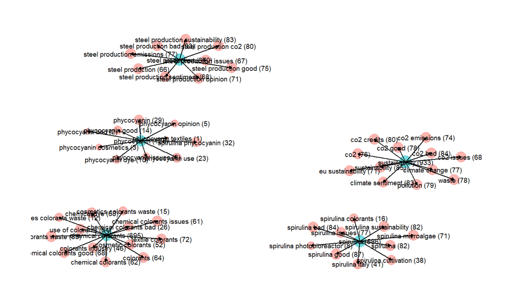

## Most common words in the titles

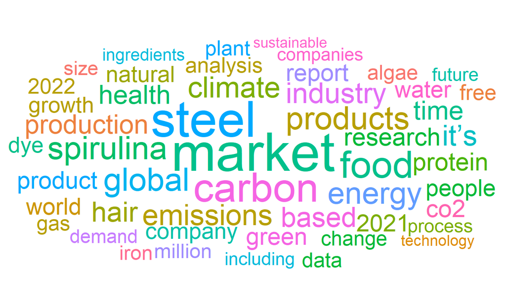

## Overall sentiment (bing)

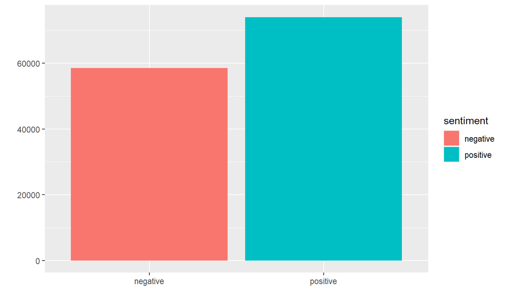

## Sustainability

Nowdays, *sustainability is a priority*.

Let’s have an overview about the general sentiment about sustainability, and identify the major trends.

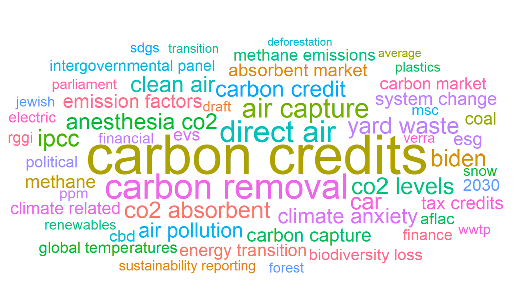

## Most common words about sustainability (loughran)

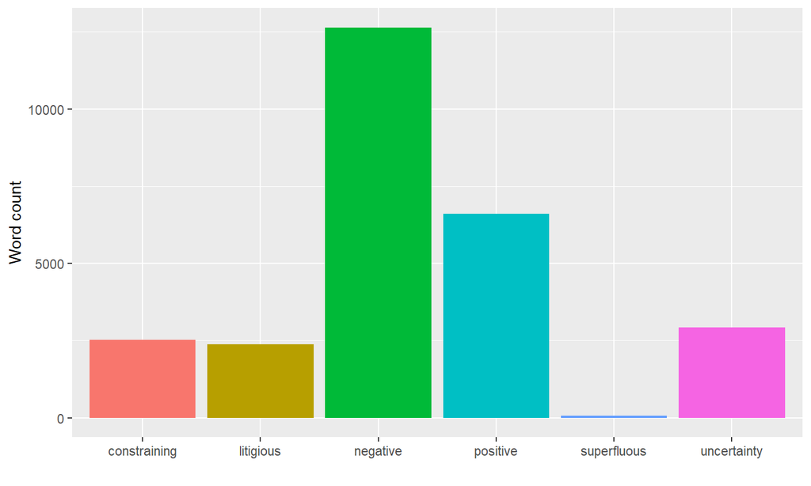

## Most negative articles (loughran)

|  | title | positive | negative | score |
| --- | --- | --- | --- | --- |
| 1 | Infertility, heart failure and kidney disease: How does climate change impact the human body? | 1 | 66 | -0.970149253731343 |
| 2 | Cost of Petone to Melling cycleway has tripled to $63m | 2 | 62 | -0.9375 |
| 3 | Climate Change and Health Equity: Key Questions and Answers | 8 | 190 | -0.919191919191919 |
| 4 | Who Feels Climate Anxiety? | 4 | 77 | -0.901234567901235 |
| 5 | Polluters are using forests as ‘carbon offsets.’ Climate change has other plans. | 10 | 128 | -0.855072463768116 |
| 6 | ‘Vicious cycle’: Storms intensify in the Gulf as climate changes | 4 | 47 | -0.843137254901961 |
| 7 | How facing your fears about the climate crisis is better for you and the planet | 6 | 70 | -0.842105263157895 |
| 8 | Dark day for humanity as number of refugees hits 100 million | 7 | 73 | -0.825 |
| 9 | Explainer: Can climate change and biodiversity loss be tackled together? | 40 | 388 | -0.813084112149533 |
| 10 | Equilibrium/Sustainability — Scientists rush to save ancient Colorado River fish | 5 | 48 | -0.811320754716981 |

[output cut: 56 more lines]

## Words per sentiment (loughran)

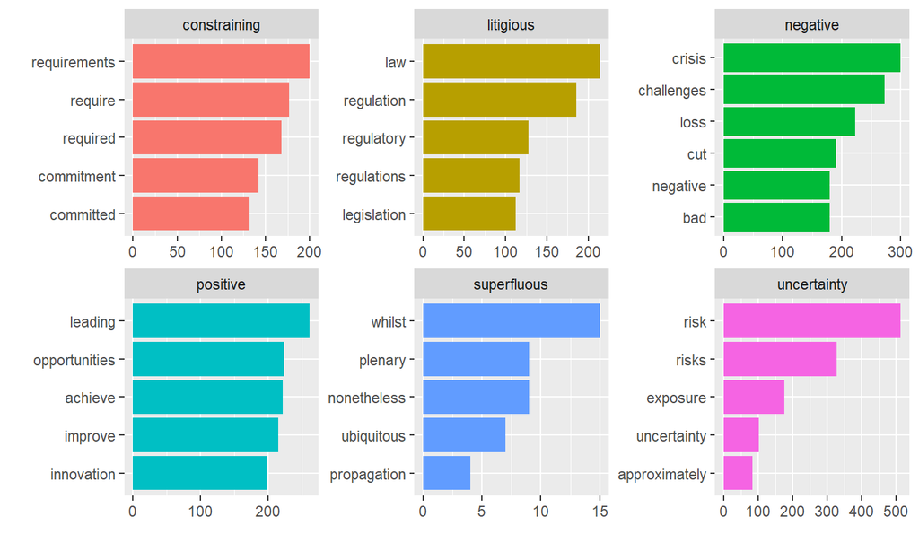

## Chemical colorants

Focussing on our target, *chemical colorants*, let’s take a deeper look about the opinion of the crowd.

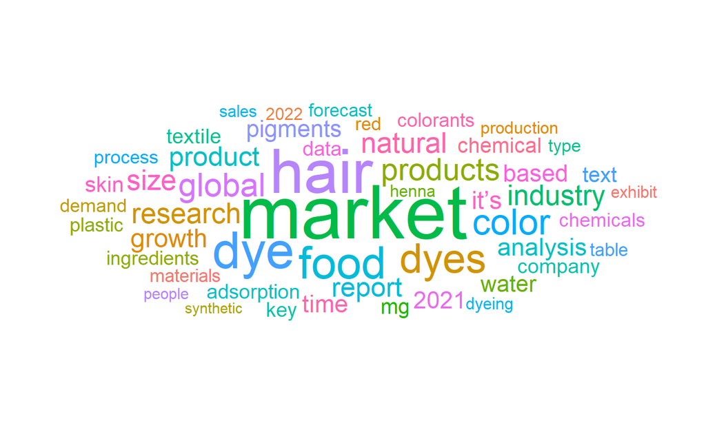

## Positive and negative words (bing)

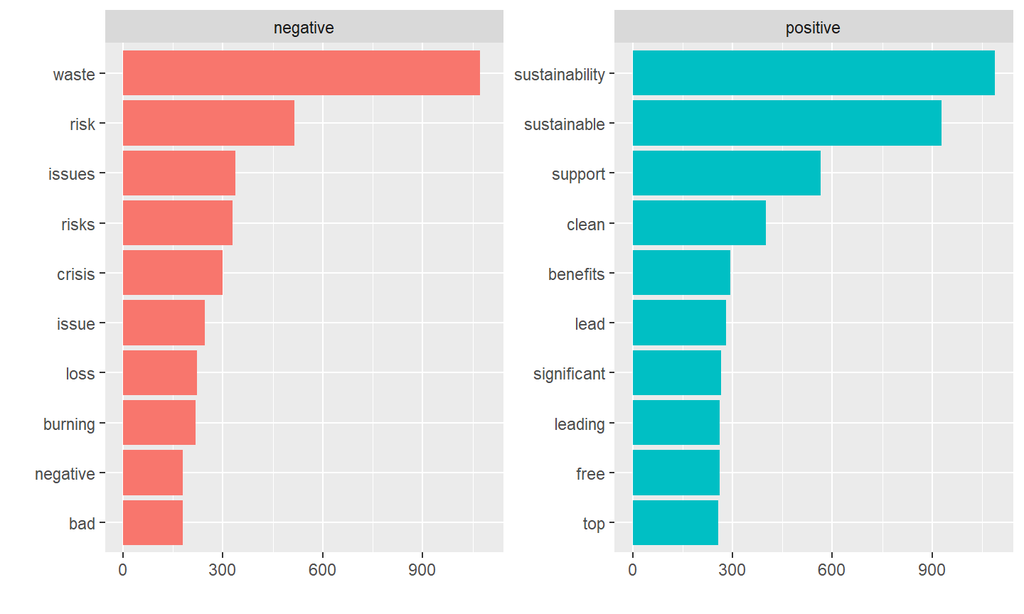

## Spirulina

One of the most famous microalgae, *Spirulina*, can be used to extract the only blue natural dye, called “Phycocyanin”.

Spirulina has also a lot of beneficial properties, and its cultivation absorbs CO2 from the athmosphere.

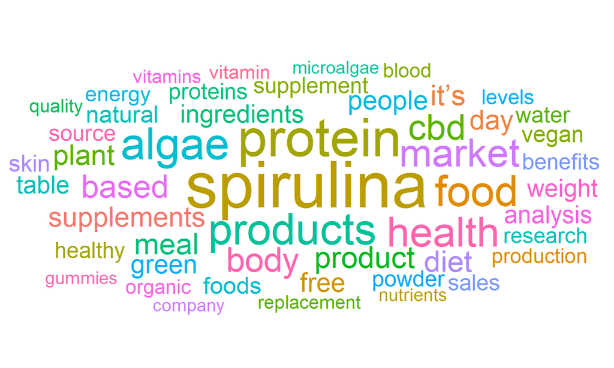

## Overall sentiment (nrc)

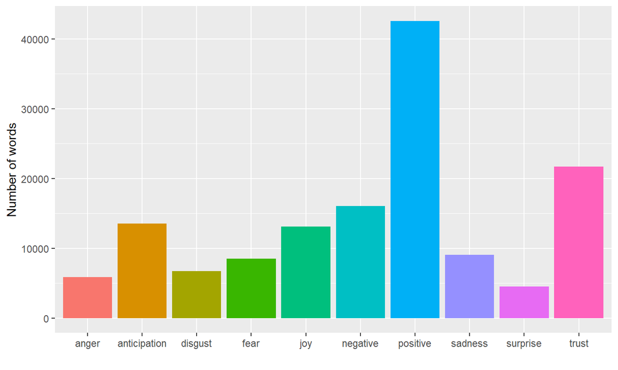

## Most common words per sentiment (nrc)

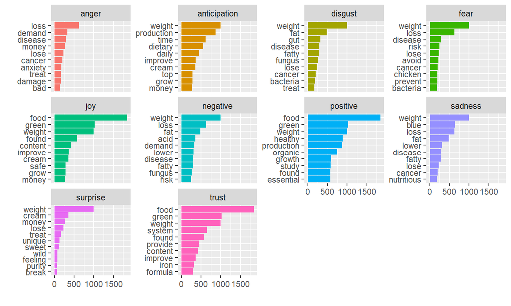

## Bigrams in most articles

|  | bigram | Number of articles |
| --- | --- | --- |
| 1 | plant based | 101 |
| 2 | blue green | 68 |
| 3 | green algae | 66 |
| 4 | health benefits | 63 |
| 5 | immune system | 63 |
| 6 | anti inflammatory | 61 |
| 7 | amino acids | 56 |
| 8 | fatty acids | 56 |
| 9 | covid 19 | 43 |
| 10 | weight loss | 37 |

[output cut: 30 more lines]

## Steel Production

We plan to cultivate spirulina *using the CO2 and heat emitted by steel plants*.

In this way, we can transform a waste into resource!

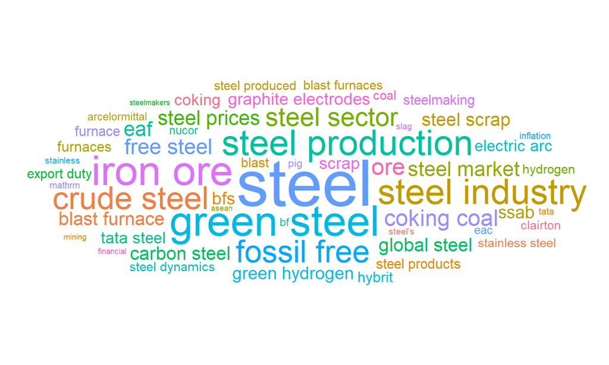

## Titles of articles about steel prod. (bing)

|  | title | negative | positive | score |
| --- | --- | --- | --- | --- |
| 1 | Fossil-free hydrogen gas storage facility opened in Sweden | 9 | 99 | 0.833333333333333 |
| 2 | Cristina Sima, TenarisSilcotub: We foster an environment where human sustainability is developed through growth from within | 16 | 94 | 0.709090909090909 |
| 3 | The iron giant: how Bryan Granzien flicked the switch on Hawsons Iron to build a world-leading project | 28 | 122 | 0.626666666666667 |
| 4 | Accelerating toward net zero: The green business building opportunity | 44 | 186 | 0.617391304347826 |
| 5 | Announcing the Sustainability Awards 2022 finalists! | 22 | 91 | 0.610619469026549 |
| 6 | Behind Volvo CE’s 'fossil-free' vehicle claim | 30 | 124 | 0.61038961038961 |
| 7 | The Best Commercial Zero-Turn Mowers of 2022 | 63 | 188 | 0.49800796812749 |
| 8 | Gearing up for green steel: how the sector plans to decarbonise | 44 | 108 | 0.421052631578947 |
| 9 | The Art of Collaboration: Insights Into Writing "Loki," Lensing "The Survivor" | 50 | 121 | 0.415204678362573 |
| 10 | Decarbonizing steel: end-to-end solutions | 69 | 153 | 0.378378378378378 |

[output cut: 48 more lines]

## Phycocyanin

Finally, here out product: *Phycocyanin*.

We believe that it will revolution the colorants industry, challenging climate change and preserving people’s health.

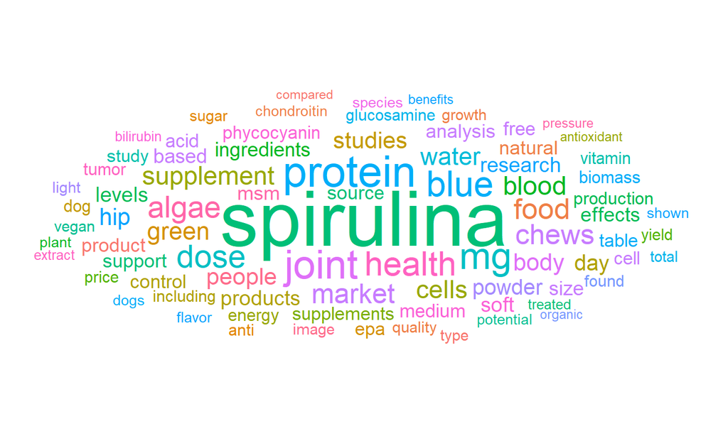

## Common sentiment about phycocyanin vs all (loughran)

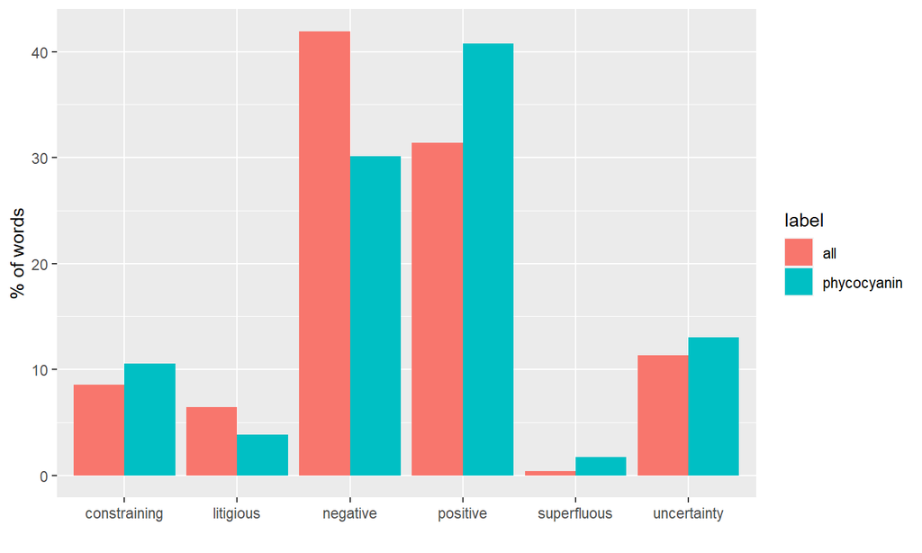

## Titles of articles about phycocyanin (bing)

|  | title | negative | positive | score |
| --- | --- | --- | --- | --- |
| 1 | Vegan Protein Powder Market Worth $8.03 Billion by 2029 | 12 | 124 | 0.823529411764706 |
| 2 | Influence of Pholiota adiposa on gut microbiota and promote tumor cell apoptosis properties in H22 tumor-bearing mice | 36 | 244 | 0.742857142857143 |
| 3 | 25 Best Dog Joint Supplements in 2022 | 248 | 920 | 0.575342465753425 |
| 4 | Start-up ‘beats the blues’ with spirulina-based food colouring for hot and cold beverages | 30 | 90 | 0.5 |
| 5 | Here are the best vegetables for your health, according to nutritionists | 36 | 90 | 0.428571428571429 |
| 6 | The best vegetables for your health, according to nutritionists | 36 | 84 | 0.4 |
| 7 | A waste-to-wealth initiative exploiting the potential of Anabaena variabilis for designing an integrated biorefinery | 69 | 153 | 0.378378378378378 |
| 8 | 10 Best Spirulina Supplements Reviewed for 2022 – Fitness Volt | 192 | 384 | 0.333333333333333 |
| 9 | Patriot Rise Up Review: Safe Ingredients or Scam Supplement? | 57 | 99 | 0.269230769230769 |
| 10 | Could Spirulina be the next super-nutraceutical to be widely grown in indoor vertical farms? | 230 | 340 | 0.192982456140351 |

[output cut: 7 more lines]

## Top bigrams

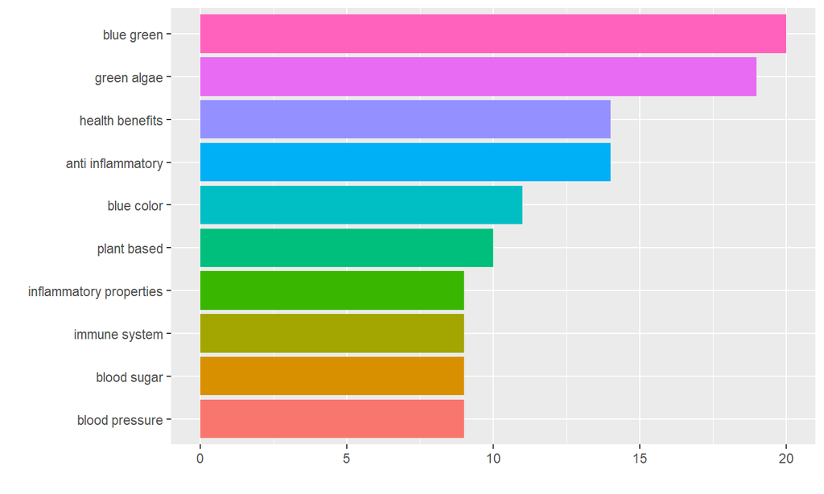

## Global positivity score (loughran)

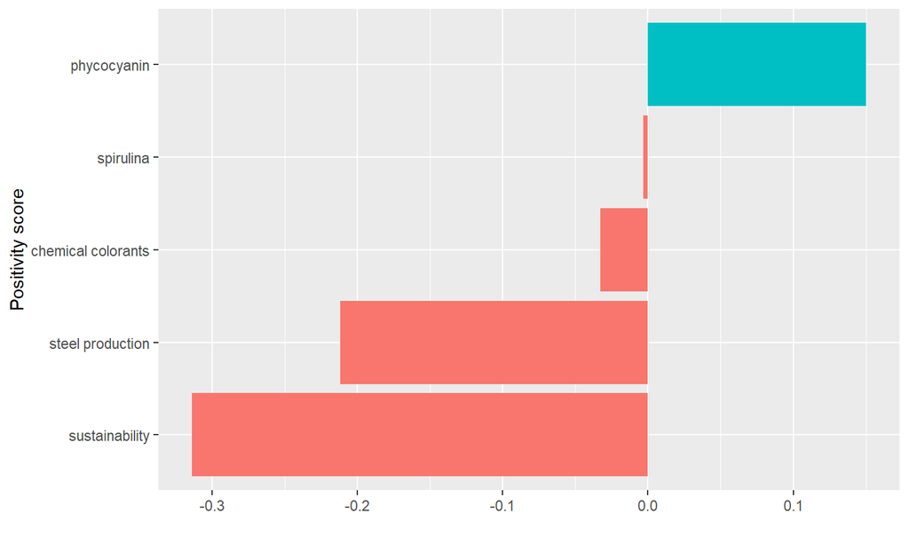

## Thanks for your attention

We are *InnoValgae*.

Come and join our *promising* *blue* *future*.